```python
%%HTML

<script>
code_show=true;
function code_toggle() {
 if (code_show){
 $('div.input').hide();
 } else {
 $('div.input').show();
 }
 code_show = !code_show
}
$( document ).ready(code_toggle);
</script>
<form action="javascript:code_toggle()"><input type="submit" value="点击按钮显示/隐藏文档代码！"></form>
```

# 苏宁小店用户价值类别判定

## 背景

根据集团"智慧零售大开发"的战略目标，苏宁小店作为战略重心，将在2018-2020三年间在全国范围内新开设超15000家苏宁小店。在苏宁小店APP上线这一段时间里，配合"三公里生活圈"营销口号和集团大量营销补贴，目前苏宁小店APP的注册用户已经环比大幅增长，如何将大量新注册用户向高质量、高价值用户转化是下一运营阶段值得深入探讨的问题，现拟抽取南京地区部分APP数据进行分析，为苏宁小店营销策略提供数据支持。

[figure not shown]

## 问题

- 补贴促销的商品利润微薄，仅是作为新用户导流的营销手段。
- 有些用户几乎只购买优惠促销的商品，极少或根本不购买正价商品，这类用户的价值较低，只会增加运营成本的负担。
- 需要将这些无价值用户从用户群体中分离，以便制定具有针对性的营销策略。

## 需求

核心需求：

```
对用户进行价值类别判定,分离出无价值用户和正常用户
分析用户行为特征对于价值类别判定的影响
```

其他需求：

```
简单分析下平台的订单情况、商品情况
做简单用户画像
```

## 数据字段简介

### 订单数据表

- 用户编号
- 订单号
- 订单完成状态
  - 0表示未完成订单
  - 1表示正常完成订单
- 是否优惠
  - 0表示无优惠
  - 1表示优惠

### 商品数据表

- 订单号
- 商品编号
- 商品名称
- 优惠额度

### 用户数据表

- 用户编号
- 登陆次数
- 生态值(基于苏宁系产品综合计算的分值)
- 订单数
- 注册时间(时间戳)
- 注册后首次下单时间(时间戳)

## 无价值用户的量化特征

优惠订单数占订单总数75%以上

```python
#载库
import numpy as np
import pandas as pd
import matplotlib.pyplot as plt
import seaborn as sns
```

```python
#忽略运行时警告
import warnings
warnings.filterwarnings("ignore")
#使用seaborn格式绘图
plt.style.use("seaborn")
#设置中文字体显示
plt.rcParams['font.family'] = ['Arial Unicode MS'] #用来正常显示中文标签
# plt.rcParams['font.family'] = ['Arial Unicode MS', 'Microsoft Yahei', 'SimHei', 'sans-serif']
```

```python
#加载表格数据
orders=pd.read_excel('data.xlsx',0)
commodities=pd.read_excel('data.xlsx',1)
users=pd.read_excel('data.xlsx',2)
```

## 表单展示

```python
orders.rename(columns={'order_id':"订单编号",'user_id':'用户编号','state':"订单状态","on_sale":"是否优惠"},inplace=True)
orders.head(3).append(orders.tail(3))
```

|  | 订单编号 | 用户编号 | 订单状态 | 是否优惠 |
| --- | --- | --- | --- | --- |
| 0 | 47739 | 5245 | 1 | 0 |
| 1 | 341269 | 5245 | 0 | 0 |
| 2 | 32690 | 5254 | 1 | 0 |
| 29147 | 447165 | 169976 | 0 | 1 |
| 29148 | 447274 | 169976 | 0 | 1 |
| 29149 | 447375 | 169976 | 1 | 1 |

```python
commodities.rename(columns={"order_id":'订单编号',"commodity_id":'商品编号',"commodity_name":"商品名称","discount":"优惠类型"},inplace=True)
commodities.head(3).append(commodities.tail(3))
```

|  | 订单编号 | 商品编号 | 商品名称 | 优惠类型 |
| --- | --- | --- | --- | --- |
| 0 | 264971 | 103247 | 苏鲜生水果礼盒 | >15 |
| 1 | 264994 | 103247 | 苏鲜生水果礼盒 | >15 |
| 2 | 266829 | 103247 | 苏鲜生水果礼盒 | >15 |
| 3127 | 284171 | 103376 | 500元苏宁卡 | 0 |
| 3128 | 256095 | 103376 | 500元苏宁卡 | 0 |
| 3129 | 256499 | 103376 | 500元苏宁卡 | 0 |

```python
users.rename(columns={'user_id':"用户编号",'exp':"生态值",'login_counts':'登陆次数',"order_counts":"订单数","time_of_register":"注册时间","time_of_initial_purchase":"首次购买时间"},inplace=True)
users.head(3).append(users.tail(3))
```

|  | 用户编号 | 生态值 | 登陆次数 | 订单数 | 注册时间 | 首次购买时间 |
| --- | --- | --- | --- | --- | --- | --- |
| 0 | 5245 | 412 | 72 | 1 | 956420152 | 963215805 |
| 1 | 5254 | 642 | 90 | 13 | 956755674 | 963092322 |
| 2 | 5286 | 560 | 75 | 1 | 956814299 | 963568191 |
| 2997 | 169832 | 310 | 9 | 1 | 1037753074 | 1037789074 |
| 2998 | 169934 | 340 | 19 | 2 | 1037801381 | 1038330606 |
| 2999 | 169976 | 135 | 12 | 1 | 1037868302 | 1037891359 |

### 订单的优惠额度种类及数量

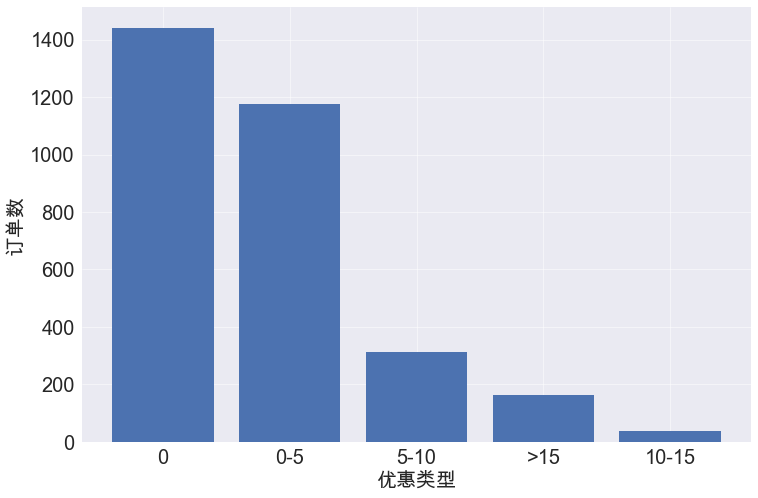

```python
discounts_kinds=commodities.groupby('优惠类型').size().sort_values(ascending=False)
plt.figure(figsize=(12,8))
plt.grid(linewidth=0.5,)
plt.xlabel('优惠类型',fontsize=20)
plt.ylabel('订单数',fontsize=20)
plt.xticks(fontsize=20)
plt.yticks(fontsize=20)
_=plt.bar(discounts_kinds.index.values,discounts_kinds.values)
# _=sns.countplot( x='优惠类型', data=commodities )
```

### 原价销量前10商品及比例关系

```python
origin=commodities[commodities['优惠类型'] == '0'].groupby('商品名称').size().sort_values(ascending=False)[:10].reset_index().set_index('商品名称').rename(columns={0: '销量'})
# origin.index.name = ''
# origin.columns.name = '商品名称'
origin.reset_index(inplace=True)
origin.index=list(range(1,11))
origin
```

|  | 商品名称 | 销量 |
| --- | --- | --- |
| 1 | 红富士苹果 | 61 |
| 2 | 脆甜红桃 | 57 |
| 3 | 东南亚进口香蕉 | 52 |
| 4 | 三全早餐三明治 | 48 |
| 5 | 鲜切果盘 | 42 |
| 6 | 桃李天然酵母面包 | 41 |
| 7 | 冰糖橙 | 40 |
| 8 | 早餐饭团 | 36 |
| 9 | 进口埃及脐橙 | 35 |
| 10 | 味全每日C | 35 |

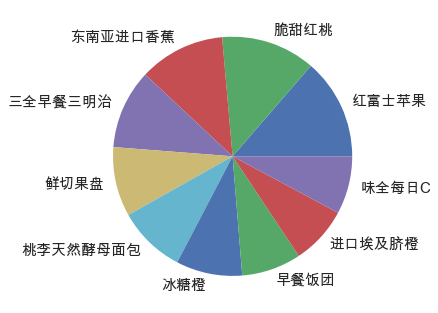

```python
origin=origin.set_index('商品名称')
patches,txt=plt.pie(origin.values,labels=origin.index.values,shadow=False)
for i in txt:
    i.set_size(15)
```

### 优惠销量前10商品及比例关系

```python
discount=commodities[commodities['优惠类型'] != '0'].groupby('商品名称').size().sort_values(ascending=False)[:10].reset_index().set_index('商品名称').rename(columns={0: '销量'})
# discount.index.name = ''
# discount.columns.name = '商品名称'
discount.reset_index(inplace=True)
discount.index=list(range(1,11))
discount
```

|  | 商品名称 | 销量 |
| --- | --- | --- |
| 1 | 土鸡蛋 | 119 |
| 2 | 不知火丑柑 | 62 |
| 3 | 畅轻燕麦酸奶 | 54 |
| 4 | 进口红心火龙果 | 41 |
| 5 | 土豆 | 39 |
| 6 | 小葱 | 39 |
| 7 | 西红柿 | 38 |
| 8 | 千禧果 | 37 |
| 9 | 水果黄瓜 | 34 |
| 10 | 小白菜 | 34 |

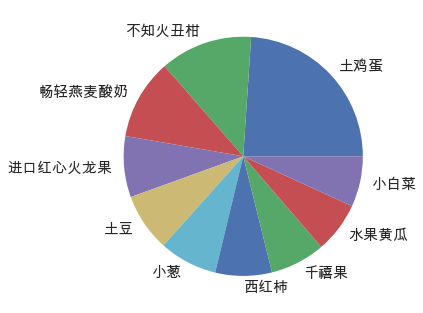

```python
discount=discount.set_index('商品名称')
patches,txt=plt.pie(discount.values,labels=discount.index.values,shadow=False)
for i in txt:
    i.set_size(15)
```

### 交叉表查看用户ID对应的正常和优惠订单的数量

```python
ct1=pd.crosstab(orders['用户编号'], orders['是否优惠'])
ct1.head().append(ct1.tail())
```

| 是否优惠 用户编号 | 0 | 1 |
| --- | --- | --- |
| 5245 | 2 | 0 |
| 5254 | 9 | 1 |
| 5286 | 7 | 1 |
| 5292 | 4 | 5 |
| 5474 | 1 | 1 |
| 169699 | 1 | 1 |
| 169815 | 0 | 1 |
| 169832 | 0 | 1 |
| 169934 | 1 | 1 |
| 169976 | 0 | 3 |

### 根据量化指标计算出无价值用户

```python
unvalued_index = ct1[(ct1[1] / ct1.sum(axis=1)) >= 0.75].index.values #算出无价值用户的用户ID
ct1['用户类别']=1 # 添加新列,将所有用户先设为有价值用户
ct1.loc[unvalued_index,'用户类别']=0 # 将无价值用户的标签置为0
users.set_index(['用户编号'],inplace=True) # 将users的用户ID设为索引,方便设置价值标签
users['用户类别']=ct1['用户类别'] # 将价值标签加入users表
users.reset_index(inplace=True) #恢复users索引

# 无价值用户共1586个
# unvalued_index.tolist() 转化成列表可方便打印或展示

# 打上价值类别标签后的用户信息表
users.head().append(users.tail())
```

|  | 用户编号 | 生态值 | 登陆次数 | 订单数 | 注册时间 | 首次购买时间 | 用户类别 |
| --- | --- | --- | --- | --- | --- | --- | --- |
| 0 | 5245 | 412 | 72 | 1 | 956420152 | 963215805 | 1 |
| 1 | 5254 | 642 | 90 | 13 | 956755674 | 963092322 | 1 |
| 2 | 5286 | 560 | 75 | 1 | 956814299 | 963568191 | 1 |
| 3 | 5292 | 643 | 240 | 5 | 956856943 | 964362416 | 1 |
| 4 | 5474 | 305 | 93 | 2 | 956974668 | 962468249 | 1 |
| 2995 | 169699 | 459 | 26 | 3 | 1037622595 | 1037928001 | 1 |
| 2996 | 169815 | 285 | 10 | 1 | 1037713437 | 1037747315 | 0 |
| 2997 | 169832 | 310 | 9 | 1 | 1037753074 | 1037789074 | 0 |
| 2998 | 169934 | 340 | 19 | 2 | 1037801381 | 1038330606 | 1 |
| 2999 | 169976 | 135 | 12 | 1 | 1037868302 | 1037891359 | 0 |

### 分类后的各类别用户数量

```python
value_category=users.groupby('用户类别').size().rename({0: '无价值用户', 1: '正常用户'})
value_category.index.name=''
value_category=pd.DataFrame(value_category)
value_category=value_category.T
value_category.index=['数量统计']
value_category
```

|  | 无价值用户 | 正常用户 |
| --- | --- | --- |
| 数量统计 | 1586 | 1414 |

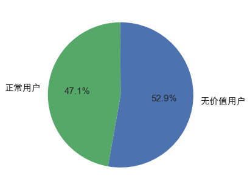

```python
_,lab,pct=plt.pie([1586,1414],labels=['无价值用户','正常用户'],autopct='%1.1f%%',startangle=-100)
for i in lab:
    i.set_size(15)
for i in pct:
    i.set_size(15)
```